# House_Prediction_Final (1) (1)

### CAPSTONE PROJECT - MILESTONE 1

#### HOUSE PRICE PREDICTION

**Context**

Housing prices are an important reflection of the economy, and housing price ranges are of great interest for both buyers and sellers. Ask a home buyer to describe their dream house, and they probably won’t begin with the height of the basement ceiling or the proximity to an east-west railroad. A house value is simply more than location and square footage. Like the features that make up a person, an educated party would want to know all aspects that give a house its value. For example, you want to sell a house and you don’t know the price which you may expect — it can’t be too low or too high. To find house price you usually try to find similar properties in your neighborhood and based on gathered data you will try to assess your house price.

**Objective**

The objective of this problem statement is to predict the housing prices of a town or a suburb based on the features of the locality provided and identify the most important features to consider while predicting the prices. Data Dictionary This dataset has 23 features, price being the target variable. The details of all the features are given below:

- cid: a notation for a house
- dayhours: Date house was sold
- price: Price is prediction target (in $)
- room_bed: Number of Bedrooms per house
- room_bath: Number of bathrooms per bedrooms
- living_measure: square footage of the home
- lot_measure: square footage of the lot
- ceil: Total floors (levels) in house
- coast: House which has a view to a waterfront (0 - No, 1 - Yes)
- sight: Has been viewed
- condition: How good the condition is (Overall out of 5)
- quality: grade given to the housing unit, based on grading system
- ceil_measure: square footage of house apart from basement
- basement_measure: square footage of the basement
- yr_built: Built Year
- yr_renovated: Year when house was renovated
- zipcode: zip code
- lat: Latitude coordinate
- long: Longitude coordinate -living_measure15: Living room area in 2015 (implies-- some renovations) This might or might not have affected the lot size area
- lot_measure15: lotSize area in 2015 (implies-- some renovations)
- furnished: Based on the quality of room (0 - No, 1 - Yes)
- total_area: Measure of both living and lot

**IMPORTING LIBRARIES**

```python
# Libraries to help with reading and manipulating data
import numpy as np
import pandas as pd

# Libraries to help with data visualization
import matplotlib.pyplot as plt
import seaborn as sns

sns.set()

# split the data into train and test
from sklearn.model_selection import train_test_split

# to build linear regression_model
from sklearn.linear_model import LinearRegression

# to check model performance
from sklearn.metrics import mean_absolute_error, mean_squared_error, r2_score

# to build linear regression_model using statsmodels
import statsmodels.api as sm

# to compute VIF
from statsmodels.stats.outliers_influence import variance_inflation_factor

from scipy.stats import pearsonr

from scipy import stats

# Setting the precision of floating numbers to 2 decimal points
pd.set_option("display.float_format", lambda x: "%.2f" % x)
```

**LOAD DATASET**

```python
House = pd.read_excel("House.xlsx")
```

```python
# copying data to another variable to avoid any changes to original data
df = House.copy()
```

**DATA OVERVIEW**

**The shape of the dataset**

```python
df.shape
```

```
(21613, 23)
```

The dataset contains information (23 attributes) about 21613 sold houses.

**Showing few rows of the dataset**

```python
df.head()
```

|  | cid | dayhours | price | room_bed | room_bath | living_measure | lot_measure | ceil | coast | sight | ... | basement | yr_built | yr_renovated | zipcode | lat | long | living_measure15 | lot_measure15 | furnished | total_area |
| --- | --- | --- | --- | --- | --- | --- | --- | --- | --- | --- | --- | --- | --- | --- | --- | --- | --- | --- | --- | --- | --- |
| 0 | 3876100940.00 | 20150427T000000 | 600000.00 | 4.00 | 1.75 | 3050.00 | 9440.00 | 1.00 | 0.00 | 0.00 | ... | 1250.00 | 1966.00 | 0.00 | 98034.00 | 47.72 | -122.18 | 2020.00 | 8660.00 | 0.00 | 12490.00 |
| 1 | 3145600250.00 | 20150317T000000 | 190000.00 | 2.00 | 1.00 | 670.00 | 3101.00 | 1.00 | 0.00 | 0.00 | ... | 0.00 | 1948.00 | 0.00 | 98118.00 | 47.55 | -122.27 | 1660.00 | 4100.00 | 0.00 | 3771.00 |
| 2 | 7129303070.00 | 20140820T000000 | 735000.00 | 4.00 | 2.75 | 3040.00 | 2415.00 | 2.00 | 1.00 | 4.00 | ... | 0.00 | 1966.00 | 0.00 | 98118.00 | 47.52 | -122.26 | 2620.00 | 2433.00 | 0.00 | 5455.00 |
| 3 | 7338220280.00 | 20141010T000000 | 257000.00 | 3.00 | 2.50 | 1740.00 | 3721.00 | 2.00 | 0.00 | 0.00 | ... | 0.00 | 2009.00 | 0.00 | 98002.00 | 47.34 | -122.21 | 2030.00 | 3794.00 | 0.00 | 5461.00 |
| 4 | 7950300670.00 | 20150218T000000 | 450000.00 | 2.00 | 1.00 | 1120.00 | 4590.00 | 1.00 | 0.00 | 0.00 | ... | 0.00 | 1924.00 | 0.00 | 98118.00 | 47.57 | -122.28 | 1120.00 | 5100.00 | 0.00 | 5710.00 |

5 rows × 23 columns

```python
df.sample(6)
```

|  | cid | dayhours | price | room_bed | room_bath | living_measure | lot_measure | ceil | coast | sight | ... | basement | yr_built | yr_renovated | zipcode | lat | long | living_measure15 | lot_measure15 | furnished | total_area |
| --- | --- | --- | --- | --- | --- | --- | --- | --- | --- | --- | --- | --- | --- | --- | --- | --- | --- | --- | --- | --- | --- |
| 18108 | 2021000180.00 | 20150310T000000 | 380000.00 | 4.00 | 2.50 | 3120.00 | 5001.00 | 2.00 | 0.00 | 0.00 | ... | 0.00 | 2005.00 | 0.00 | 98023.00 | 47.28 | -122.35 | 3120.00 | 5244.00 | 1.00 | 8121.00 |
| 13989 | 1238500978.00 | 20140922T000000 | 365000.00 | 3.00 | 1.00 | 950.00 | 8450.00 | 1.00 | 0.00 | 0.00 | ... | 0.00 | 1962.00 | 0.00 | 98033.00 | 47.69 | -122.19 | 1610.00 | 10080.00 | 0.00 | 9400.00 |
| 41 | 731500200.00 | 20150113T000000 | 347500.00 | 4.00 | 2.50 | 2156.00 | 3562.00 | 2.00 | 0.00 | 0.00 | ... | 0.00 | 2012.00 | 0.00 | 98030.00 | 47.36 | -122.20 | 1708.00 | 3539.00 | 1.00 | 5718.00 |
| 4239 | 4151800410.00 | 20141031T000000 | 1350000.00 | 5.00 | 3.25 | 3540.00 | 5971.00 | 1.00 | 0.00 | 2.00 | ... | 1540.00 | 2005.00 | 0.00 | 98033.00 | 47.66 | -122.20 | 2820.00 | 6029.00 | 1.00 | 9511.00 |
| 7238 | 1840000030.00 | 20140529T000000 | 267500.00 | 3.00 | 1.75 | 1590.00 | 11914.00 | 1.00 | 0.00 | 2.00 | ... | 500.00 | 1957.00 | 0.00 | 98188.00 | 47.44 | -122.27 | 1630.00 | 9052.00 | 0.00 | 13504.00 |
| 12960 | 255450340.00 | 20140827T000000 | 387865.00 | 3.00 | 2.50 | 2370.00 | 4200.00 | 2.00 | 0.00 | 0.00 | ... | 0.00 | 2014.00 | 0.00 | 98038.00 | 47.37 | -122.02 | 2370.00 | 4200.00 | 0.00 | 6570.00 |

6 rows × 23 columns

**Checking the data types of the columns for the dataset**

```python
df.info()
```

```
<class 'pandas.core.frame.DataFrame'>
RangeIndex: 21613 entries, 0 to 21612
Data columns (total 23 columns):
 #   Column            Non-Null Count  Dtype
---  ------            --------------  -----
 0   cid               21613 non-null  float64
 1   dayhours          21613 non-null  object
 2   price             21613 non-null  float64
 3   room_bed          21505 non-null  float64
 4   room_bath         21505 non-null  float64
 5   living_measure    21596 non-null  float64
 6   lot_measure       21571 non-null  float64
 7   ceil              21571 non-null  object
 8   coast             21612 non-null  object
 9   sight             21556 non-null  float64
 10  condition         21556 non-null  object
 11  quality           21612 non-null  float64
 12  ceil_measure      21612 non-null  float64
 13  basement          21612 non-null  float64
 14  yr_built          21612 non-null  object
 15  yr_renovated      21613 non-null  float64
 16  zipcode           21613 non-null  float64
 17  lat               21613 non-null  float64
 18  long              21613 non-null  object
 19  living_measure15  21447 non-null  float64
 20  lot_measure15     21584 non-null  float64
 21  furnished         21584 non-null  float64
 22  total_area        21584 non-null  object
dtypes: float64(16), object(7)
memory usage: 3.8+ MB
```

**Checking for Missing values with original data**

```python
df.isnull().sum()
```

```
cid                   0
dayhours              0
price                 0
room_bed            108
room_bath           108
living_measure       17
lot_measure          42
ceil                 42
coast                 1
sight                57
condition            57
quality               1
ceil_measure          1
basement              1
yr_built              1
yr_renovated          0
zipcode               0
lat                   0
long                  0
living_measure15    166
lot_measure15        29
furnished            29
total_area           29
dtype: int64
```

**Check for Duplicate values**

```python
df.duplicated().sum()
```

```
0
```

There are no duplicated values.

**DATA PRE-PROCESSING FOR DESCRIPTIVE STATISTICS & EDA**

**Fixing messy columns; Columns that have '$' replace with NaN**

```python
# Find columns with '$' symbol
columns_with_dollar = [col for col in df.columns if any('$' in value for value in df[col].astype(str))]

# Display columns with '$'
print("Columns with '$':", columns_with_dollar)
```

```
Columns with '$': ['ceil', 'coast', 'condition', 'yr_built', 'long', 'total_area']
```

```python
# Replace '$' with N laN in the entire DataFrame
df = df.applymap(lambda x: np.nan if isinstance(x, str) and '$' in x else x)
```

**Checking for missing values after removing "$"**

```python
df.isnull().sum()
```

```
cid                   0
dayhours              0
price                 0
room_bed            108
room_bath           108
living_measure       17
lot_measure          42
ceil                 72
coast                31
sight                57
condition            85
quality               1
ceil_measure          1
basement              1
yr_built             15
yr_renovated          0
zipcode               0
lat                   0
long                 34
living_measure15    166
lot_measure15        29
furnished            29
total_area           68
dtype: int64
```

**Compare the results - Missing values (Original Date) and Missing Values (After removing $)**

```python
df_ = pd.DataFrame({'Missing_Value_Original_Data':House.isnull().sum(), 'Missing_Value_after_Remov_$': df.isnull().sum()})
df_
```

|  | Missing_Value_Original_Data | Missing_Value_after_Remov_$ |
| --- | --- | --- |
| cid | 0 | 0 |
| dayhours | 0 | 0 |
| price | 0 | 0 |
| room_bed | 108 | 108 |
| room_bath | 108 | 108 |
| living_measure | 17 | 17 |
| lot_measure | 42 | 42 |
| ceil | 42 | 72 |
| coast | 1 | 31 |
| sight | 57 | 57 |
| condition | 57 | 85 |
| quality | 1 | 1 |
| ceil_measure | 1 | 1 |
| basement | 1 | 1 |
| yr_built | 1 | 15 |
| yr_renovated | 0 | 0 |
| zipcode | 0 | 0 |
| lat | 0 | 0 |
| long | 0 | 34 |
| living_measure15 | 166 | 166 |
| lot_measure15 | 29 | 29 |
| furnished | 29 | 29 |
| total_area | 29 | 68 |

Coumns with the missing values:

- room_bed
- room_bath
- living_measure
- lot_measure
- ceil
- coast
- sight
- condition
- quality
- ceil_measure
- basement
- yr_built
- long
- living_measure15
- lot_measure15
- furnished
- total_area

**Re-checking Datatype**

```python
df.info()
```

```
<class 'pandas.core.frame.DataFrame'>
RangeIndex: 21613 entries, 0 to 21612
Data columns (total 23 columns):
 #   Column            Non-Null Count  Dtype
---  ------            --------------  -----
 0   cid               21613 non-null  float64
 1   dayhours          21613 non-null  object
 2   price             21613 non-null  float64
 3   room_bed          21505 non-null  float64
 4   room_bath         21505 non-null  float64
 5   living_measure    21596 non-null  float64
 6   lot_measure       21571 non-null  float64
 7   ceil              21541 non-null  float64
 8   coast             21582 non-null  float64
 9   sight             21556 non-null  float64
 10  condition         21528 non-null  float64
 11  quality           21612 non-null  float64
 12  ceil_measure      21612 non-null  float64
 13  basement          21612 non-null  float64
 14  yr_built          21598 non-null  float64
 15  yr_renovated      21613 non-null  float64
 16  zipcode           21613 non-null  float64
 17  lat               21613 non-null  float64
 18  long              21579 non-null  float64
 19  living_measure15  21447 non-null  float64
 20  lot_measure15     21584 non-null  float64
 21  furnished         21584 non-null  float64
 22  total_area        21545 non-null  float64
dtypes: float64(22), object(1)
memory usage: 3.8+ MB
```

- After fixing the coulmns, we have 1 object and 22 are numeric variables.

**Descriptive Statistics**

```python
df.describe(include='all').T
```

|  | count | unique | top | freq | mean | std | min | 25% | 50% | 75% | max |
| --- | --- | --- | --- | --- | --- | --- | --- | --- | --- | --- | --- |
| cid | 21613.00 | NaN | NaN | NaN | 4580301520.86 | 2876565571.31 | 1000102.00 | 2123049194.00 | 3904930410.00 | 7308900445.00 | 9900000190.00 |
| dayhours | 21613 | 372 | 20140623T000000 | 142 | NaN | NaN | NaN | NaN | NaN | NaN | NaN |
| price | 21613.00 | NaN | NaN | NaN | 540182.16 | 367362.23 | 75000.00 | 321950.00 | 450000.00 | 645000.00 | 7700000.00 |
| room_bed | 21505.00 | NaN | NaN | NaN | 3.37 | 0.93 | 0.00 | 3.00 | 3.00 | 4.00 | 33.00 |
| room_bath | 21505.00 | NaN | NaN | NaN | 2.12 | 0.77 | 0.00 | 1.75 | 2.25 | 2.50 | 8.00 |
| living_measure | 21596.00 | NaN | NaN | NaN | 2079.86 | 918.50 | 290.00 | 1429.25 | 1910.00 | 2550.00 | 13540.00 |
| lot_measure | 21571.00 | NaN | NaN | NaN | 15104.58 | 41423.62 | 520.00 | 5040.00 | 7618.00 | 10684.50 | 1651359.00 |
| ceil | 21541.00 | NaN | NaN | NaN | 1.49 | 0.54 | 1.00 | 1.00 | 1.50 | 2.00 | 3.50 |
| coast | 21582.00 | NaN | NaN | NaN | 0.01 | 0.09 | 0.00 | 0.00 | 0.00 | 0.00 | 1.00 |
| sight | 21556.00 | NaN | NaN | NaN | 0.23 | 0.77 | 0.00 | 0.00 | 0.00 | 0.00 | 4.00 |
| condition | 21528.00 | NaN | NaN | NaN | 3.41 | 0.65 | 1.00 | 3.00 | 3.00 | 4.00 | 5.00 |
| quality | 21612.00 | NaN | NaN | NaN | 7.66 | 1.18 | 1.00 | 7.00 | 7.00 | 8.00 | 13.00 |
| ceil_measure | 21612.00 | NaN | NaN | NaN | 1788.37 | 828.10 | 290.00 | 1190.00 | 1560.00 | 2210.00 | 9410.00 |
| basement | 21612.00 | NaN | NaN | NaN | 291.52 | 442.58 | 0.00 | 0.00 | 0.00 | 560.00 | 4820.00 |
| yr_built | 21598.00 | NaN | NaN | NaN | 1971.01 | 29.37 | 1900.00 | 1951.00 | 1975.00 | 1997.00 | 2015.00 |
| yr_renovated | 21613.00 | NaN | NaN | NaN | 84.40 | 401.68 | 0.00 | 0.00 | 0.00 | 0.00 | 2015.00 |
| zipcode | 21613.00 | NaN | NaN | NaN | 98077.94 | 53.51 | 98001.00 | 98033.00 | 98065.00 | 98118.00 | 98199.00 |
| lat | 21613.00 | NaN | NaN | NaN | 47.56 | 0.14 | 47.16 | 47.47 | 47.57 | 47.68 | 47.78 |
| long | 21579.00 | NaN | NaN | NaN | -122.21 | 0.14 | -122.52 | -122.33 | -122.23 | -122.12 | -121.31 |
| living_measure15 | 21447.00 | NaN | NaN | NaN | 1987.07 | 685.52 | 399.00 | 1490.00 | 1840.00 | 2360.00 | 6210.00 |
| lot_measure15 | 21584.00 | NaN | NaN | NaN | 12766.54 | 27286.99 | 651.00 | 5100.00 | 7620.00 | 10087.00 | 871200.00 |
| furnished | 21584.00 | NaN | NaN | NaN | 0.20 | 0.40 | 0.00 | 0.00 | 0.00 | 0.00 | 1.00 |
| total_area | 21545.00 | NaN | NaN | NaN | 17192.04 | 41628.69 | 1423.00 | 7032.00 | 9575.00 | 13000.00 | 1652659.00 |

**Exploratory Data Analysis (EDA)**

- EDA is an important part of any project involving data.
- It is important to investigate and understand the data better before building a model with it.
- A few questions have been mentioned below which will help you approach the analysis in the right manner and generate insights from the data.
- A thorough analysis of the data, in addition to the questions mentioned below, should be done.

**Dropping houses with no bedrooms and bathrooms**

```python
# Let study houses with no bedrooms
Zero_R = df[df['room_bed']==0]
Zero_R
```

|  | cid | dayhours | price | room_bed | room_bath | living_measure | lot_measure | ceil | coast | sight | ... | basement | yr_built | yr_renovated | zipcode | lat | long | living_measure15 | lot_measure15 | furnished | total_area |
| --- | --- | --- | --- | --- | --- | --- | --- | --- | --- | --- | --- | --- | --- | --- | --- | --- | --- | --- | --- | --- | --- |
| 3155 | 2954400190.00 | 20140624T000000 | 1300000.00 | 0.00 | 0.00 | 4810.00 | 28008.00 | 2.00 | 0.00 | 0.00 | ... | 0.00 | 1990.00 | 0.00 | 98053.00 | 47.66 | -122.07 | 4740.00 | 35061.00 | 1.00 | 32818.00 |
| 3286 | 2569500210.00 | 20141117T000000 | 339950.00 | 0.00 | 2.50 | 2290.00 | 8319.00 | 2.00 | 0.00 | 0.00 | ... | 0.00 | 1985.00 | 0.00 | 98042.00 | 47.35 | -122.15 | 2500.00 | 8751.00 | 0.00 | 10609.00 |
| 3405 | 3980300371.00 | 20140926T000000 | 142000.00 | 0.00 | 0.00 | 290.00 | 20875.00 | 1.00 | 0.00 | 0.00 | ... | 0.00 | 1963.00 | 0.00 | 98024.00 | 47.53 | -121.89 | 1620.00 | 22850.00 | 0.00 | 21165.00 |
| 4238 | 7849202190.00 | 20141223T000000 | 235000.00 | 0.00 | 0.00 | 1470.00 | 4800.00 | 2.00 | 0.00 | 0.00 | ... | 0.00 | 1996.00 | 0.00 | 98065.00 | 47.53 | -121.83 | 1060.00 | 7200.00 | 0.00 | 6270.00 |
| 8340 | 7849202299.00 | 20150218T000000 | 320000.00 | 0.00 | 2.50 | 1490.00 | 7111.00 | 2.00 | 0.00 | 0.00 | ... | 0.00 | 1999.00 | 0.00 | 98065.00 | 47.53 | -121.83 | 1500.00 | 4675.00 | 0.00 | 8601.00 |
| 8877 | 1453602309.00 | 20140805T000000 | 288000.00 | 0.00 | 1.50 | 1430.00 | 1650.00 | 3.00 | 0.00 | 0.00 | ... | 0.00 | 1999.00 | 0.00 | 98125.00 | 47.72 | -122.29 | 1430.00 | 1650.00 | 0.00 | 3080.00 |
| 14922 | 1222029077.00 | 20141029T000000 | 265000.00 | 0.00 | 0.75 | 384.00 | 213444.00 | 1.00 | 0.00 | 0.00 | ... | 0.00 | 2003.00 | 0.00 | 98070.00 | 47.42 | -122.49 | 1920.00 | 224341.00 | 0.00 | 213828.00 |
| 15593 | 3918400017.00 | 20150205T000000 | 380000.00 | 0.00 | 0.00 | 1470.00 | 979.00 | 3.00 | 0.00 | 2.00 | ... | 0.00 | 2006.00 | 0.00 | 98133.00 | 47.71 | -122.36 | 1470.00 | 1399.00 | 0.00 | 2449.00 |
| 17704 | 3374500520.00 | 20150429T000000 | 355000.00 | 0.00 | 0.00 | 2460.00 | 8049.00 | 2.00 | 0.00 | 0.00 | ... | 0.00 | 1990.00 | 0.00 | 98031.00 | 47.41 | -122.17 | 2520.00 | 8050.00 | 0.00 | 10509.00 |
| 17859 | 6896300380.00 | 20141002T000000 | 228000.00 | 0.00 | 1.00 | 390.00 | 5900.00 | 1.00 | 0.00 | 0.00 | ... | 0.00 | 1953.00 | 0.00 | 98118.00 | 47.53 | -122.26 | 2170.00 | 6000.00 | 0.00 | 6290.00 |
| 18283 | 2310060040.00 | 20140925T000000 | 240000.00 | 0.00 | 2.50 | 1810.00 | 5669.00 | 2.00 | 0.00 | 0.00 | ... | 0.00 | 2003.00 | 0.00 | 98038.00 | 47.35 | -122.05 | 1810.00 | 5685.00 | 0.00 | 7479.00 |
| 18596 | 9543000205.00 | 20150413T000000 | 139950.00 | 0.00 | 0.00 | 844.00 | 4269.00 | 1.00 | 0.00 | 0.00 | ... | 0.00 | 1913.00 | 0.00 | 98001.00 | 47.28 | -122.25 | 1380.00 | 9600.00 | 0.00 | 5113.00 |
| 20957 | 6306400140.00 | 20140612T000000 | 1100000.00 | 0.00 | 0.00 | 3064.00 | 4764.00 | 3.50 | 0.00 | 2.00 | ... | 0.00 | 1990.00 | 0.00 | 98102.00 | 47.64 | -122.32 | 2360.00 | 4000.00 | 0.00 | 7828.00 |

13 rows × 23 columns

```python
# lets check the count of houses with no bathromms
Zero_Bath = df[df['room_bath']==0]
Zero_Bath
```

|  | cid | dayhours | price | room_bed | room_bath | living_measure | lot_measure | ceil | coast | sight | ... | basement | yr_built | yr_renovated | zipcode | lat | long | living_measure15 | lot_measure15 | furnished | total_area |
| --- | --- | --- | --- | --- | --- | --- | --- | --- | --- | --- | --- | --- | --- | --- | --- | --- | --- | --- | --- | --- | --- |
| 3155 | 2954400190.00 | 20140624T000000 | 1300000.00 | 0.00 | 0.00 | 4810.00 | 28008.00 | 2.00 | 0.00 | 0.00 | ... | 0.00 | 1990.00 | 0.00 | 98053.00 | 47.66 | -122.07 | 4740.00 | 35061.00 | 1.00 | 32818.00 |
| 3405 | 3980300371.00 | 20140926T000000 | 142000.00 | 0.00 | 0.00 | 290.00 | 20875.00 | 1.00 | 0.00 | 0.00 | ... | 0.00 | 1963.00 | 0.00 | 98024.00 | 47.53 | -121.89 | 1620.00 | 22850.00 | 0.00 | 21165.00 |
| 4238 | 7849202190.00 | 20141223T000000 | 235000.00 | 0.00 | 0.00 | 1470.00 | 4800.00 | 2.00 | 0.00 | 0.00 | ... | 0.00 | 1996.00 | 0.00 | 98065.00 | 47.53 | -121.83 | 1060.00 | 7200.00 | 0.00 | 6270.00 |
| 4730 | 203100435.00 | 20140918T000000 | 484000.00 | 1.00 | 0.00 | 690.00 | 23244.00 | 1.00 | 0.00 | 0.00 | ... | 0.00 | 1948.00 | 0.00 | 98053.00 | 47.64 | -121.95 | 1690.00 | 19290.00 | 0.00 | 23934.00 |
| 15593 | 3918400017.00 | 20150205T000000 | 380000.00 | 0.00 | 0.00 | 1470.00 | 979.00 | 3.00 | 0.00 | 2.00 | ... | 0.00 | 2006.00 | 0.00 | 98133.00 | 47.71 | -122.36 | 1470.00 | 1399.00 | 0.00 | 2449.00 |
| 17704 | 3374500520.00 | 20150429T000000 | 355000.00 | 0.00 | 0.00 | 2460.00 | 8049.00 | 2.00 | 0.00 | 0.00 | ... | 0.00 | 1990.00 | 0.00 | 98031.00 | 47.41 | -122.17 | 2520.00 | 8050.00 | 0.00 | 10509.00 |
| 17946 | 3421079032.00 | 20150217T000000 | 75000.00 | 1.00 | 0.00 | 670.00 | 43377.00 | 1.00 | 0.00 | 0.00 | ... | 0.00 | 1966.00 | 0.00 | 98022.00 | 47.26 | -121.91 | 1160.00 | 42882.00 | 0.00 | 44047.00 |
| 18596 | 9543000205.00 | 20150413T000000 | 139950.00 | 0.00 | 0.00 | 844.00 | 4269.00 | 1.00 | 0.00 | 0.00 | ... | 0.00 | 1913.00 | 0.00 | 98001.00 | 47.28 | -122.25 | 1380.00 | 9600.00 | 0.00 | 5113.00 |
| 20355 | 5702500050.00 | 20141104T000000 | 280000.00 | 1.00 | 0.00 | 600.00 | 24501.00 | 1.00 | 0.00 | 0.00 | ... | 0.00 | 1950.00 | 0.00 | 98045.00 | 47.53 | -121.75 | 990.00 | 22549.00 | 0.00 | 25101.00 |
| 20957 | 6306400140.00 | 20140612T000000 | 1100000.00 | 0.00 | 0.00 | 3064.00 | 4764.00 | 3.50 | 0.00 | 2.00 | ... | 0.00 | 1990.00 | 0.00 | 98102.00 | 47.64 | -122.32 | 2360.00 | 4000.00 | 0.00 | 7828.00 |

10 rows × 23 columns

```python
# lets check for houses with no bedrooms and bathrooms
House_ = df[(df['room_bed'] == 0) & (df['room_bath'] == 0)]
House_
```

|  | cid | dayhours | price | room_bed | room_bath | living_measure | lot_measure | ceil | coast | sight | ... | basement | yr_built | yr_renovated | zipcode | lat | long | living_measure15 | lot_measure15 | furnished | total_area |
| --- | --- | --- | --- | --- | --- | --- | --- | --- | --- | --- | --- | --- | --- | --- | --- | --- | --- | --- | --- | --- | --- |
| 3155 | 2954400190.00 | 20140624T000000 | 1300000.00 | 0.00 | 0.00 | 4810.00 | 28008.00 | 2.00 | 0.00 | 0.00 | ... | 0.00 | 1990.00 | 0.00 | 98053.00 | 47.66 | -122.07 | 4740.00 | 35061.00 | 1.00 | 32818.00 |
| 3405 | 3980300371.00 | 20140926T000000 | 142000.00 | 0.00 | 0.00 | 290.00 | 20875.00 | 1.00 | 0.00 | 0.00 | ... | 0.00 | 1963.00 | 0.00 | 98024.00 | 47.53 | -121.89 | 1620.00 | 22850.00 | 0.00 | 21165.00 |
| 4238 | 7849202190.00 | 20141223T000000 | 235000.00 | 0.00 | 0.00 | 1470.00 | 4800.00 | 2.00 | 0.00 | 0.00 | ... | 0.00 | 1996.00 | 0.00 | 98065.00 | 47.53 | -121.83 | 1060.00 | 7200.00 | 0.00 | 6270.00 |
| 15593 | 3918400017.00 | 20150205T000000 | 380000.00 | 0.00 | 0.00 | 1470.00 | 979.00 | 3.00 | 0.00 | 2.00 | ... | 0.00 | 2006.00 | 0.00 | 98133.00 | 47.71 | -122.36 | 1470.00 | 1399.00 | 0.00 | 2449.00 |
| 17704 | 3374500520.00 | 20150429T000000 | 355000.00 | 0.00 | 0.00 | 2460.00 | 8049.00 | 2.00 | 0.00 | 0.00 | ... | 0.00 | 1990.00 | 0.00 | 98031.00 | 47.41 | -122.17 | 2520.00 | 8050.00 | 0.00 | 10509.00 |
| 18596 | 9543000205.00 | 20150413T000000 | 139950.00 | 0.00 | 0.00 | 844.00 | 4269.00 | 1.00 | 0.00 | 0.00 | ... | 0.00 | 1913.00 | 0.00 | 98001.00 | 47.28 | -122.25 | 1380.00 | 9600.00 | 0.00 | 5113.00 |
| 20957 | 6306400140.00 | 20140612T000000 | 1100000.00 | 0.00 | 0.00 | 3064.00 | 4764.00 | 3.50 | 0.00 | 2.00 | ... | 0.00 | 1990.00 | 0.00 | 98102.00 | 47.64 | -122.32 | 2360.00 | 4000.00 | 0.00 | 7828.00 |

7 rows × 23 columns

- There are 13 houses with no bedrooms, 10 houses with no bathrooms
- 7 houses have no bedrooms and bathrooms
- These houses need to be dropped from the dataset as they may have been collected in error.

```python
# Dropping houses with no bedrooms and bathrooms
df = df[df['room_bed'] != 0]
```

```python
df = df[df['room_bath'] != 0]
```

```python
df
```

|  | cid | dayhours | price | room_bed | room_bath | living_measure | lot_measure | ceil | coast | sight | ... | basement | yr_built | yr_renovated | zipcode | lat | long | living_measure15 | lot_measure15 | furnished | total_area |
| --- | --- | --- | --- | --- | --- | --- | --- | --- | --- | --- | --- | --- | --- | --- | --- | --- | --- | --- | --- | --- | --- |
| 0 | 3876100940.00 | 20150427T000000 | 600000.00 | 4.00 | 1.75 | 3050.00 | 9440.00 | 1.00 | 0.00 | 0.00 | ... | 1250.00 | 1966.00 | 0.00 | 98034.00 | 47.72 | -122.18 | 2020.00 | 8660.00 | 0.00 | 12490.00 |
| 1 | 3145600250.00 | 20150317T000000 | 190000.00 | 2.00 | 1.00 | 670.00 | 3101.00 | 1.00 | 0.00 | 0.00 | ... | 0.00 | 1948.00 | 0.00 | 98118.00 | 47.55 | -122.27 | 1660.00 | 4100.00 | 0.00 | 3771.00 |
| 2 | 7129303070.00 | 20140820T000000 | 735000.00 | 4.00 | 2.75 | 3040.00 | 2415.00 | 2.00 | 1.00 | 4.00 | ... | 0.00 | 1966.00 | 0.00 | 98118.00 | 47.52 | -122.26 | 2620.00 | 2433.00 | 0.00 | 5455.00 |
| 3 | 7338220280.00 | 20141010T000000 | 257000.00 | 3.00 | 2.50 | 1740.00 | 3721.00 | 2.00 | 0.00 | 0.00 | ... | 0.00 | 2009.00 | 0.00 | 98002.00 | 47.34 | -122.21 | 2030.00 | 3794.00 | 0.00 | 5461.00 |
| 4 | 7950300670.00 | 20150218T000000 | 450000.00 | 2.00 | 1.00 | 1120.00 | 4590.00 | 1.00 | 0.00 | 0.00 | ... | 0.00 | 1924.00 | 0.00 | 98118.00 | 47.57 | -122.28 | 1120.00 | 5100.00 | 0.00 | 5710.00 |
| ... | ... | ... | ... | ... | ... | ... | ... | ... | ... | ... | ... | ... | ... | ... | ... | ... | ... | ... | ... | ... | ... |
| 21608 | 203600600.00 | 20150310T000000 | 685530.00 | 4.00 | 2.50 | 3130.00 | 60467.00 | 2.00 | 0.00 | 0.00 | ... | 0.00 | 1996.00 | 0.00 | 98014.00 | 47.66 | -121.96 | 2780.00 | 44224.00 | 1.00 | 63597.00 |
| 21609 | 625049281.00 | 20140521T000000 | 535000.00 | 2.00 | 1.00 | 1030.00 | 4841.00 | 1.00 | 0.00 | 0.00 | ... | 110.00 | 1939.00 | 0.00 | 98103.00 | 47.69 | -122.34 | 1530.00 | 4944.00 | 0.00 | 5871.00 |
| 21610 | 424069018.00 | 20140905T000000 | 998000.00 | 3.00 | 3.75 | 3710.00 | 34412.00 | 2.00 | 0.00 | 0.00 | ... | 800.00 | 1978.00 | 0.00 | 98075.00 | 47.59 | -122.04 | 2390.00 | 34412.00 | 1.00 | 38122.00 |
| 21611 | 7258200055.00 | 20150206T000000 | 262000.00 | 4.00 | 2.50 | 1560.00 | 7800.00 | 2.00 | 0.00 | 0.00 | ... | 0.00 | 1997.00 | 0.00 | 98168.00 | 47.51 | -122.32 | 1160.00 | 7800.00 | 0.00 | 9360.00 |
| 21612 | 8805900430.00 | 20141229T000000 | 1150000.00 | 4.00 | 2.50 | 1940.00 | 4875.00 | 2.00 | 0.00 | 0.00 | ... | 0.00 | 1925.00 | 0.00 | 98112.00 | 47.64 | -122.30 | 1790.00 | 4875.00 | 1.00 | 6815.00 |

21597 rows × 23 columns

```python
21613-21597
```

```
16
```

- 16 house with no bedrooms or bathrooms have been removed from the dataset.
- Now, the houses are 21,597 in number.

```python
# df.to_csv('Downloads/FE.csv',index=False)
```

**Rounding up Bathrooms values - values should not be float or decimal**

```python
import math
```

```python
df['room_bath'] = df['room_bath'].apply(lambda x: math.ceil(x) if not math.isnan(x) else x)
```

```python
 # df.to_csv('Downloads/FE1.csv',index=False)
```

**How the variables correlate with each other**

```python
# copy the dataset and keep the original dataset
Bivariate = df.copy()
```

```python
Bivariate.head(3)
```

|  | cid | dayhours | price | room_bed | room_bath | living_measure | lot_measure | ceil | coast | sight | ... | basement | yr_built | yr_renovated | zipcode | lat | long | living_measure15 | lot_measure15 | furnished | total_area |
| --- | --- | --- | --- | --- | --- | --- | --- | --- | --- | --- | --- | --- | --- | --- | --- | --- | --- | --- | --- | --- | --- |
| 0 | 3876100940.00 | 20150427T000000 | 600000.00 | 4.00 | 2.00 | 3050.00 | 9440.00 | 1.00 | 0.00 | 0.00 | ... | 1250.00 | 1966.00 | 0.00 | 98034.00 | 47.72 | -122.18 | 2020.00 | 8660.00 | 0.00 | 12490.00 |
| 1 | 3145600250.00 | 20150317T000000 | 190000.00 | 2.00 | 1.00 | 670.00 | 3101.00 | 1.00 | 0.00 | 0.00 | ... | 0.00 | 1948.00 | 0.00 | 98118.00 | 47.55 | -122.27 | 1660.00 | 4100.00 | 0.00 | 3771.00 |
| 2 | 7129303070.00 | 20140820T000000 | 735000.00 | 4.00 | 3.00 | 3040.00 | 2415.00 | 2.00 | 1.00 | 4.00 | ... | 0.00 | 1966.00 | 0.00 | 98118.00 | 47.52 | -122.26 | 2620.00 | 2433.00 | 0.00 | 5455.00 |

3 rows × 23 columns

```python
# drop columns that are not needed for correlation analysis
colu = ['cid', 'dayhours','zipcode']
Bivariate = Bivariate.drop(colu, axis=1)
```

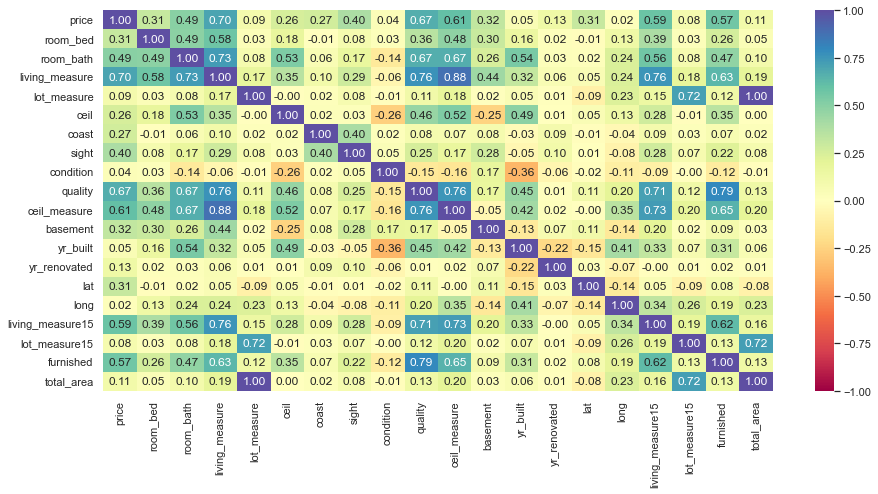

```python
# Plotting heatmap to show how the varaibles correlate with each other.
plt.figure(figsize=(15, 7))
sns.heatmap(Bivariate.corr(), annot=True, vmin=-1, vmax=1, fmt=".2f", cmap="Spectral")
plt.show()
```

**The below functions need to be defined to carry out the EDA**

```python
# function to plot a boxplot and a histogram along the same scale.

def histogram_boxplot(df, feature, figsize=(15, 10), kde=True, bins=None):
    """
    Boxplot and histogram combined

    data: dataframe
    feature: dataframe column
    figsize: size of figure (default (15,10))
    kde: whether to show the density curve (default False)
    bins: number of bins for histogram (default None)
    """
    f2, (ax_box2, ax_hist2) = plt.subplots(
        nrows=2,  # Number of rows of the subplot grid= 2
        sharex=True,  # x-axis will be shared among all subplots
        gridspec_kw={"height_ratios": (0.25, 0.75)},
        figsize=figsize,
    )  # creating the 2 subplots
    sns.boxplot(
        data=df, x=feature, ax=ax_box2, showmeans=True, color="violet"
    )  # boxplot will be created and a triangle will indicate the mean value of the column
    sns.histplot(
        data=df, x=feature, kde=kde, ax=ax_hist2, bins=bins
    ) if bins else sns.histplot(
        data=df, x=feature, kde=kde, ax=ax_hist2
    )  # For histogram
    ax_hist2.axvline(
        df[feature].mean(), color="green", linestyle="--"
    )  # Add mean to the histogram
    ax_hist2.axvline(
        df[feature].median(), color="black", linestyle="-"
    )  # Add median to the histogram
```

```python
# function to create labeled barplots

def labeled_barplot(df, feature, perc=False, n=None):
    """
    Barplot with percentage at the top

    data: dataframe
    feature: dataframe column
    perc: whether to display percentages instead of count (default is False)
    n: displays the top n category levels (default is None, i.e., display all levels)
    """

    total = len(df[feature])  # length of the column
    count = df[feature].nunique()
    if n is None:
        plt.figure(figsize=(count + 2, 6))
    else:
        plt.figure(figsize=(n + 2, 6))

    plt.xticks(rotation=90, fontsize=15)
    ax = sns.countplot(
        data=df,
        x=feature,
        palette="Paired",
        order=df[feature].value_counts().index[:n],
    )

    for p in ax.patches:
        if perc == True:
            label = "{:.1f}%".format(
                100 * p.get_height() / total
            )  # percentage of each class of the category
        else:
            label = p.get_height()  # count of each level of the category

        x = p.get_x() + p.get_width() / 2  # width of the plot
        y = p.get_height()  # height of the plot

        ax.annotate(
            label,
            (x, y),
            ha="center",
            va="center",
            size=12,
            xytext=(0, 5),
            textcoords="offset points",
        )  # annotate the percentage

    plt.show()  # show the plot
```

```python
def stacked_barplot(data, predictor, target):
    """
    Print the category counts and plot a stacked bar chart

    data: dataframe
    predictor: independent variable
    target: target variable
    """
    count = df[predictor].nunique()
    sorter = df[target].value_counts().index[-1]
    tab1 = pd.crosstab(df[predictor], df[target], margins=True).sort_values(
        by=sorter, ascending=False
    )
    print(tab1)
    print("-" * 120)
    tab = pd.crosstab(df[predictor], df[target], normalize="index").sort_values(
        by=sorter, ascending=False
    )
    tab.plot(kind="bar", stacked=True, figsize=(count + 5, 5))
    plt.legend(
        loc="lower left", frameon=False,
    )
    plt.legend(loc="upper left", bbox_to_anchor=(1, 1))
    plt.show()
```

**The distribution of `Prices of the houses`**

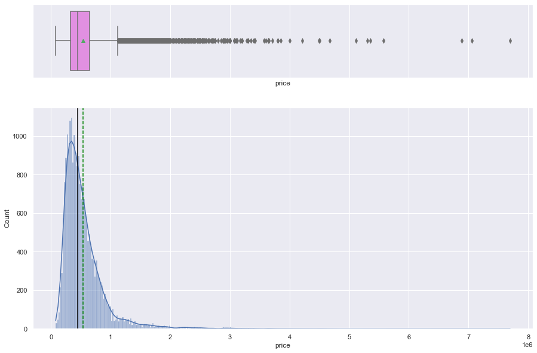

```python
histogram_boxplot(df, "price")
```

```python
Pr = df.copy()

# Calculating the 25th quantile
Q1 = Pr["price"].quantile(0.25)

# Calculating the 75th quantile
Q3 = Pr["price"].quantile(0.75)

# Calculating IQR
IQR = Q3 - Q1

# Calculating value of upper whisker
Upper_Whisker = Q3 + 1.5 * IQR
print('The value of Upper_Whisker is '+'$ '+str(Upper_Whisker))
```

```
The value of Upper_Whisker is $ 1129500.0
```

```python
df_price = Pr[Pr.price > 1129500.0]
df_price.shape
```

```
(1158, 23)
```

```python
# % of houses with higher prices
percentage = (len(df_price) / len(Pr)) * 100

# Display the percentage
print(f"Percentage of houses with 'prices' > 1129500.0: {percentage:.2f}%")
```

```
Percentage of houses with 'prices' > 1129500.0: 5.36%
```

```python
# Check for median - appropriate due to the presence of outliers
median = Pr["price"].median()
print('The median price of the houses is $' + str(round(median, 2)))
```

```
The median price of the houses is $450000.0
```

**Observation**

- The price distribution is skewed to the right with many high outliers. This suggests that more than 50% of the houses have lower prices.
- About 5.4% of houses (1,158) are identified as having high prices, exceeding $1,129,500.00.

**The Distribution of `total_area (lot_measure + living_measure)`**

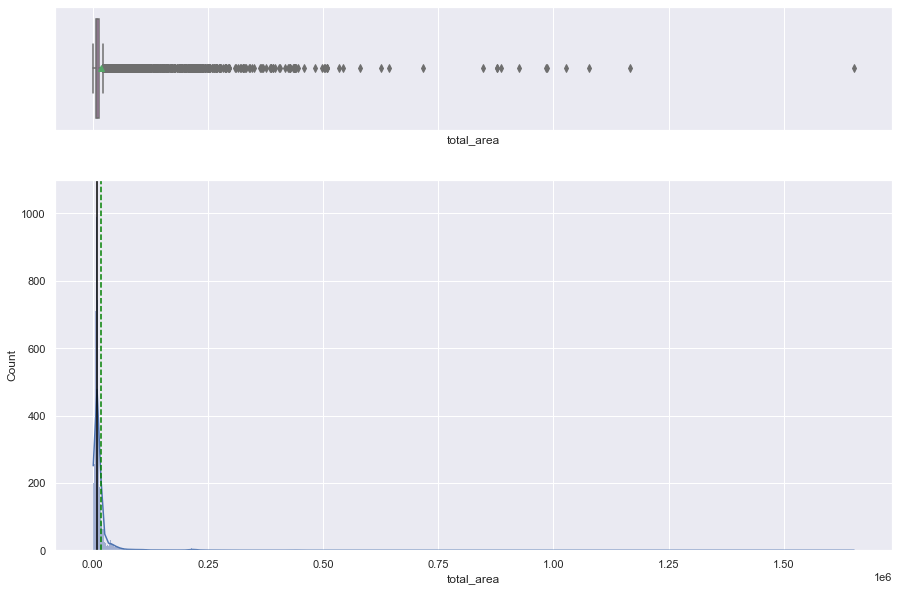

```python
histogram_boxplot(df, "total_area")
```

```python
Area = df.copy()
# Calculating the 25th quantile
Q1 = Area["total_area"].quantile(0.25)

# Calculating the 75th quantile
Q3 = Area["total_area"].quantile(0.75)

# Calculating IQR
IQR = Q3 - Q1

# Calculating value of upper whisker
Upper_Whisker = Q3 + 1.5 * IQR
print('The value of Upper_Whisker is '+str(Upper_Whisker) + ' square footage')
```

```
The value of Upper_Whisker is 21949.5 square footage
```

```python
df_area = Area[Area['total_area'] > 21949.5]
df_area.shape
```

```
(2406, 23)
```

```python
# % of houses with higher area
percentage = (len(df_area) / len(Area)) * 100

# Display the percentage
print(f"Percentage of houses with prices > 21949.5: {percentage:.2f}%")
```

```
Percentage of houses with prices > 21949.5: 11.14%
```

**Observation**

- The `total_area` distribution is skewed to the fight with many high outliers. This suggests that more than 50% of the houses have low sqaure areas.
- About 11% of houses (2,406) are identified as having large area, exceeding 21,949.5 square footage.
- The total area has no correlation with house price, lets check the distribution for `lot_measure` and `living_measure`

**Lets check the dristribution of `living_measure`**

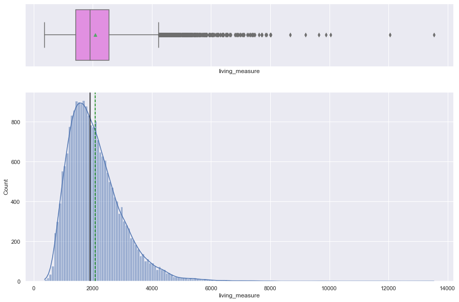

```python
histogram_boxplot(df, "living_measure")
```

- The distribution of the house living area is skewed to the right with few high outliers.
- 50% and slightly more houses have lower living area.

**Price and Living room area have high correlation, lets study the plot**

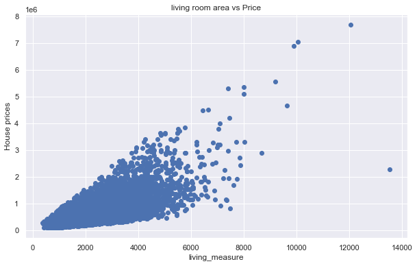

```python
plt.figure(figsize=(10, 6))
plt.scatter(df['living_measure'], df['price'])
plt.title("living room area vs Price")
plt.xlabel('living_measure')
plt.ylabel('House prices')
plt.grid(True)
plt.show()
```

- There is a high correlation concentration upto a 6000 square footage area, and the plot spreads beyond 6000 sqft area

**Lets check the distribution of lot_measure**

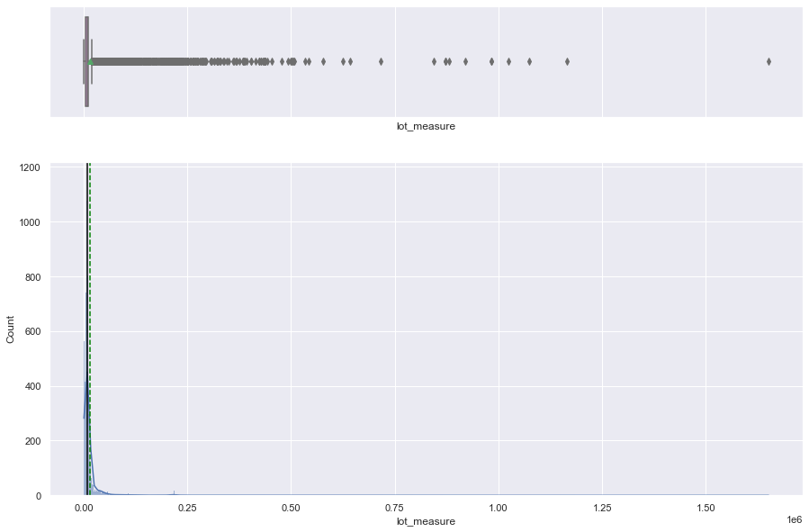

```python
histogram_boxplot(df, "lot_measure")
```

- `total_area` and `lot_measure` appear to have the same distribution - that is, right skewed distribution with hihg outliers.
- This suggest a perfect correlation between them as shown in the correlation heatmap - There is collinearity

**lets study the correlation between `total_area` and `lot_measure`**

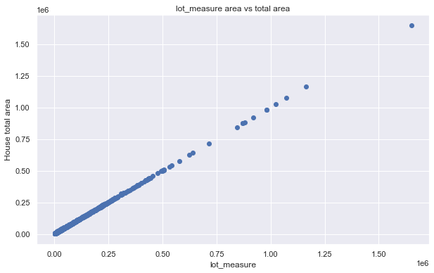

```python
plt.figure(figsize=(10, 6))
plt.scatter(df['lot_measure'], df['total_area'])
plt.title("lot_measure area vs total area")
plt.xlabel('lot_measure')
plt.ylabel('House total area')
plt.grid(True)
plt.show()
```

- All the points are on the straight line, indicating a perfect correlation - presence of collinearity.

**Observation of the square footage of house apart from basement**

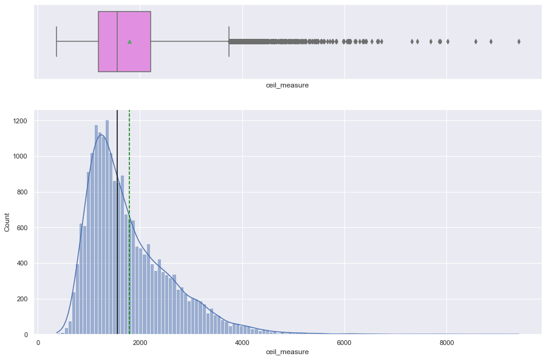

```python
histogram_boxplot(df, "ceil_measure")
```

```python
cm = df.copy()
# Calculating the 25th quantile
Q1 = cm["ceil_measure"].quantile(0.25)

# Calculating the 75th quantile
Q3 = cm["ceil_measure"].quantile(0.75)

# Calculating IQR
IQR = Q3 - Q1

# Calculating value of upper whisker
Upper_Whisker = Q3 + 1.5 * IQR
print('The value of Upper_Whisker is '+str(Upper_Whisker))
```

```
The value of Upper_Whisker is 3740.0
```

```python
df_cm = cm[cm['ceil_measure'] > 3740.0]
df_cm.shape
```

```
(610, 23)
```

```python
# % of houses with larger house area
percentage = (len(df_cm) / len(cm)) * 100

# Display the percentage
print(f"Percentage of houses with square footage > 3740.0: {percentage:.2f}%")
```

```
Percentage of houses with square footage > 3740.0: 2.82%
```

**Observation**

- Out of 21597, 610 houses have large square footage areas apart from basement
- comparatively, about 97% of the houses have quite low square footage area.
- `living_measure` and `ceil_measure` appear to have similar distribution, suggesting collinearity.

**Lets study their correlation**

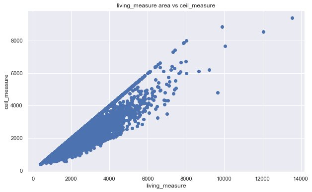

```python
plt.figure(figsize=(10, 6))
plt.scatter(df['living_measure'], df['ceil_measure'])
plt.title("living_measure area vs ceil_measure")
plt.xlabel('living_measure')
plt.ylabel('ceil_measure')
plt.grid(True)
plt.show()
```

- living measure and ceil measure are correlated. There is collinearity.

**Lets check the distribution of basement area**

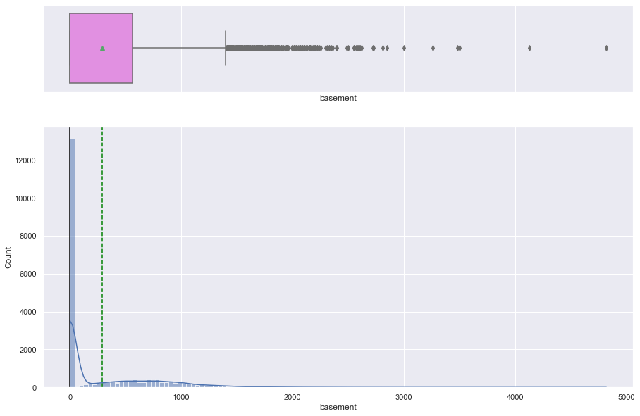

```python
histogram_boxplot(df, "basement")
```

```python
Zero_B = df[df['basement'] == 0]
Zero_B.shape
```

```
(13109, 23)
```

**Observation**

- More that 50% of the houses have no basement. However, there are few houses with large square footage area of basement.

**Lets check how prices of the houses vary with house with Basement**

```python
House_B = df[df['basement'] > 0]
House_B.shape
```

```
(8487, 23)
```

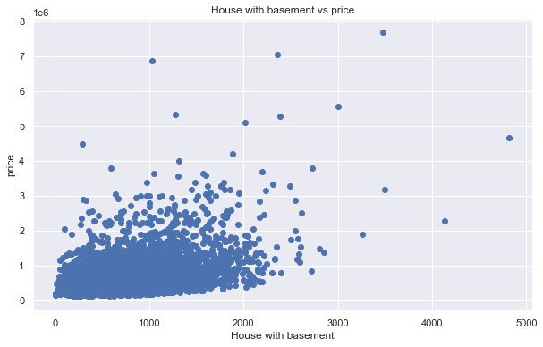

```python
plt.figure(figsize=(10, 6))
plt.scatter(House_B['basement'], House_B['price'])
plt.title("House with basement vs price")
plt.xlabel('House with basement')
plt.ylabel('price')
plt.grid(True)
plt.show()
```

**Observation of the Number of Bedrooms per house**

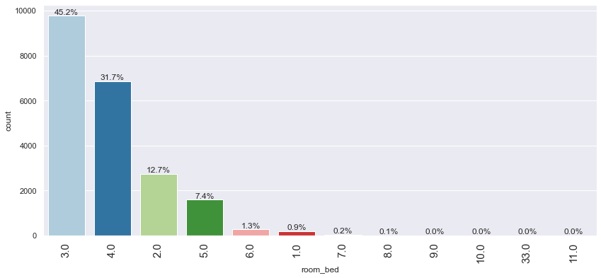

```python
labeled_barplot(df, "room_bed",perc=True, n=12)
```

- Three (3) bedroom houses have the highest frequency in the dataset follow by 4 bedroom houses
- 11, 33, 10, 9, 8, and 7 bedroom houses appear to be few in the dataset.

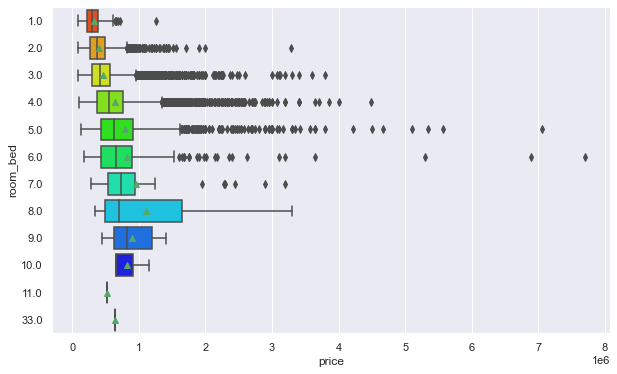

```python
plt.figure(figsize=(10, 6))
sns.boxplot(
    data=df, y="room_bed", x="price", palette="gist_rainbow", orient='h',showmeans=True
)
plt.show()
```

- Due to the presence of outiers, the general price for the number of bedrooms per house is set at the median price
- Generally, Houses with more bedrooms have higher prices that houses with few bedrooms

**Observation of the Number of Bathrooms per house**

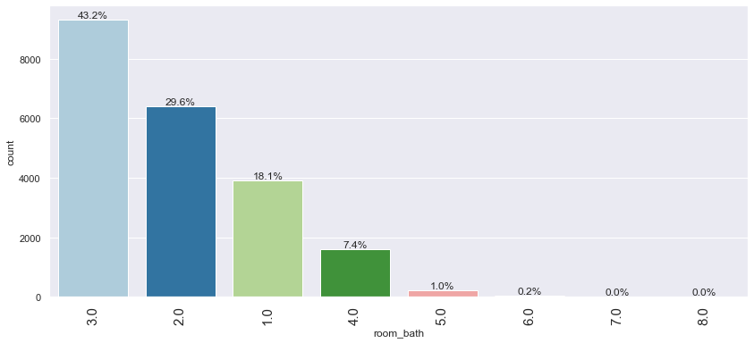

```python
labeled_barplot(df, "room_bath",perc=True, n=12)
```

- Houses with three (3) bathrooms have the highest frequency in the dataset follow by houses with 2 bathrooms
- Houses with 8, 7, 6, and 5 bathrooms appear to be few in the dataset.

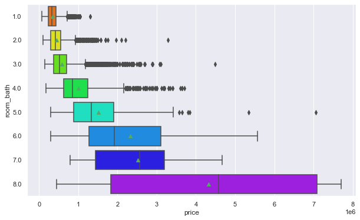

```python
plt.figure(figsize=(10, 6))
sns.boxplot(
    data=df, y="room_bath", x="price", palette="gist_rainbow", orient='h',showmeans=True
)
plt.show()
```

- Generally, houses with more bathrooms appear to have higher prices than houses with few bathrooms.

**Lets check the distribution of bedrooms per house against their bathrooms**

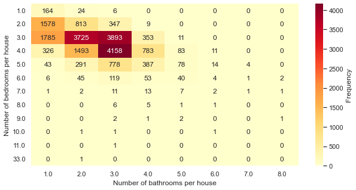

```python
plt.figure(figsize=(10, 5))
sns.heatmap(pd.crosstab(df['room_bed'], df['room_bath']),
            annot=True,
            fmt="g",
            cmap="YlOrRd",
            cbar_kws={'label': 'Frequency'})  # Adding colorbar label
plt.ylabel("Number of bedrooms per house")
plt.xlabel("Number of bathrooms per house")
plt.yticks(rotation=0)  # Rotating y-axis labels
plt.show()
```

- 4 bedrom houses with 3 bathrooms appear to have the highest frequency in the dataset followed by 3 bederom and 3 bathroom houses, then 3 bederom houses with 2 bathrooms.
- Prices of houses with few bedrooms and bathrooms have lower prices than houses with plenty bedrooms and bathrooms.

**% of Furnished and Unfurnished Houses**

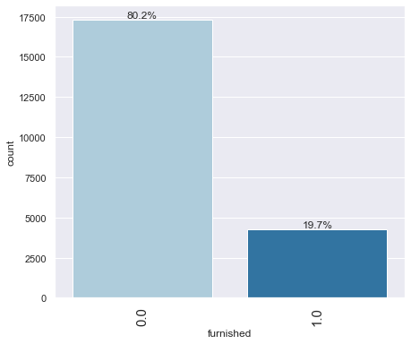

```python
 labeled_barplot(df, "furnished", perc=True, n=5)
```

- About 80% of the houses are not furnished

**What are the differences in prices for furnished and unfurnished houses**

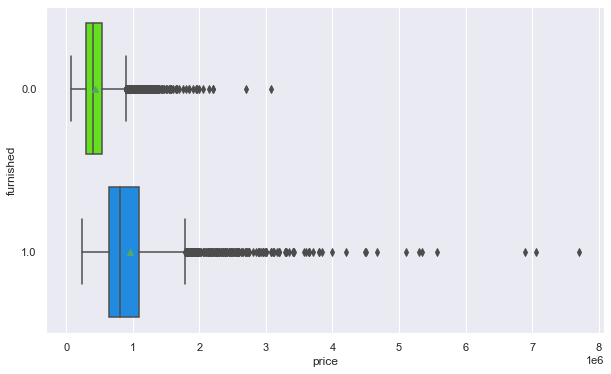

```python
plt.figure(figsize=(10, 6))
sns.boxplot(
    data=df, y="furnished", x="price", palette="gist_rainbow", orient='h',showmeans=True
)
plt.show()
```

- Generally, furnished houses have higher prices than unfurnished houses.

**quality**

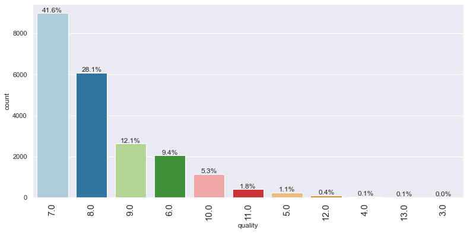

```python
 labeled_barplot(df, "quality", perc=True)
```

- About 42% of the house were graded 7 and 28% were graded 8 moderate quality.
- Houses graded 3, 4, 5, and 6 could be suggested a low quality houses and house graded 9, 10, 11, 12 and 13 could also be suggested as high quality houses.
- High quality house and low quality houses are very few in the dataset

**Lets check if the houses quality may have impact on the prices**

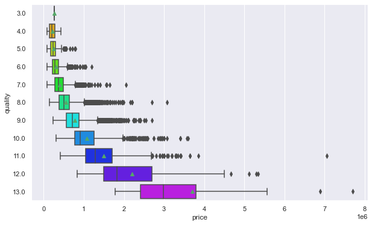

```python
plt.figure(figsize=(10, 6))
sns.boxplot(
    data=df, y="quality", x="price", palette="gist_rainbow", orient='h',showmeans=True
)
plt.show()
```

- Generally high quality houses have higher prices than lower quality houses.
- comparatively, moderate quality houses have moderate prices.

**Furnishing Houses is based on quality, lets check how quality impact house furnishing**

```
furnished    0.0   1.0    All
quality
All        17322  4245  21567
9.0            0  2612   2612
10.0           0  1132   1132
11.0           0   399    399
12.0           0    89     89
13.0           0    13     13
3.0            1     0      1
4.0           27     0     27
5.0          241     0    241
6.0         2035     0   2035
7.0         8965     0   8965
8.0         6053     0   6053
------------------------------------------------------------------------------------------------------------------------
```

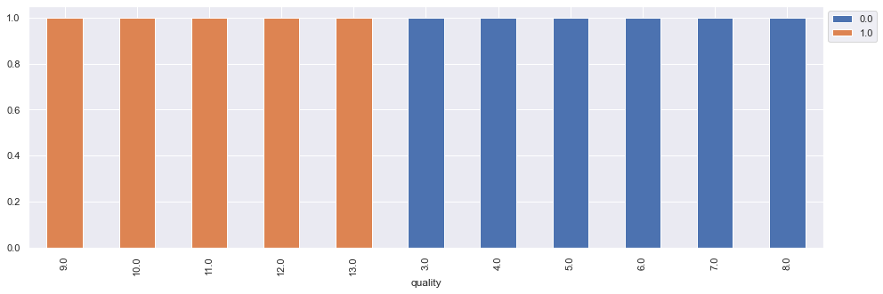

```python
stacked_barplot(df, "quality", "furnished")
```

- High quality houses (graded 9 - 13) are furnished house while low and moderate quality(graded 3- 8) houses are non-furnished houses.

**The conditions of the houses**

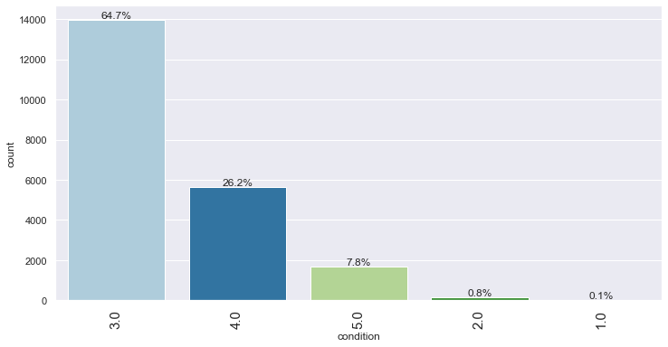

```python
 labeled_barplot(df, "condition", perc=True, n=10)
```

**how the condition of a house influences its price**

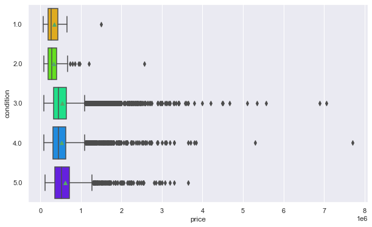

```python
plt.figure(figsize=(10, 6))
sns.boxplot(
    data=df, y="condition", x="price", palette="gist_rainbow", orient='h',showmeans=True
)
plt.show()
```

**sight**

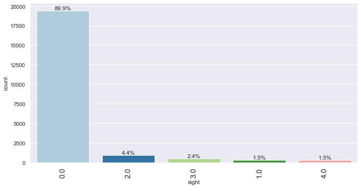

```python
labeled_barplot(df, "sight", perc=True, n=10)
```

```
furnished    0.0   1.0    All
sight
All        17276  4235  21511
0.0        16100  3294  19394
2.0          593   364    957
3.0          239   271    510
4.0          121   197    318
1.0          223   109    332
------------------------------------------------------------------------------------------------------------------------
```

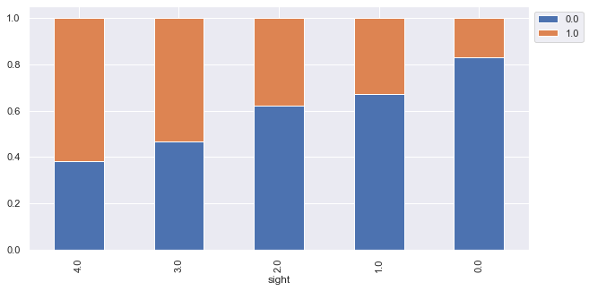

```python
stacked_barplot(df, "sight", "furnished")
```

- Furnished houses attract a lot of views than non furnished houses.

**sight vs price**

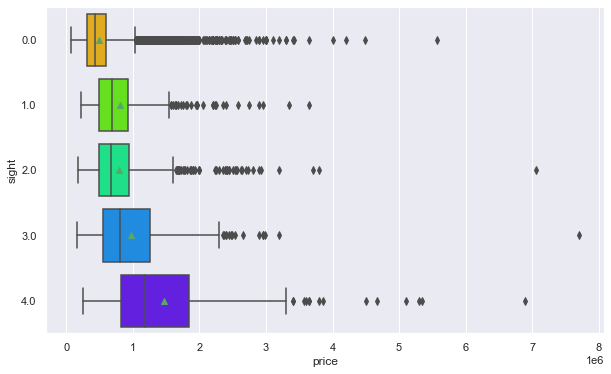

```python
plt.figure(figsize=(10, 6))
sns.boxplot(
    data=df, y="sight", x="price", palette="gist_rainbow", orient='h',showmeans=True
)
plt.show()
```

**Houses with a view to a waterfront often have higher prices**

- Lets check the count or % of Houses with and without waterfront
- How these outdoor feature impact the house prices.

**coast**

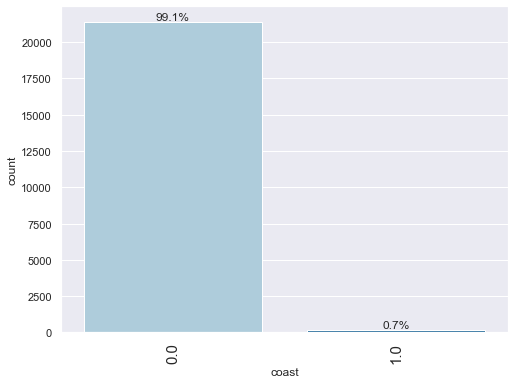

```python
labeled_barplot(df, "coast", perc=True, n=6)
```

```
coast    0.0  1.0    All
sight
All    21349  161  21510
4.0      183  134    317
3.0      489   18    507
2.0      948    8    956
1.0      331    1    332
0.0    19398    0  19398
------------------------------------------------------------------------------------------------------------------------
```

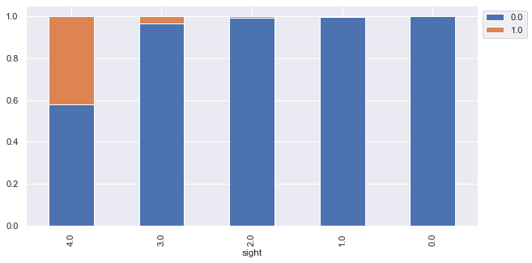

```python
stacked_barplot(df, "sight", "coast")
```

- Houses with waterfront attract a lot of views.

**Coast vs Price**

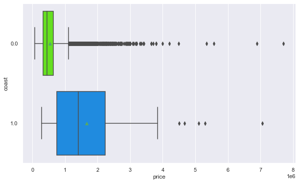

```python
plt.figure(figsize=(10, 6))
sns.boxplot(
    data=df, y="coast", x="price", palette="gist_rainbow", orient='h',showmeans=True
)
plt.show()
```

- Generally, houses with waterfront attract higher prices.

**DATA PRE-PROCESSING FOR MODEL BUILDING**

- Missing value treatment
- Outlier detection and treatment (if needed)
- Preparing data for modeling
- Any other preprocessing steps (if needed)

**Missing Value Treatment:**

- Using the variables median values due to the presence of outliers.
- Using the variables mean values when there are no outliers
- room_bed
- room_bath
- living_measure
- lot_measure
- ceil
- coast
- sight
- condition
- quality
- ceil_measure
- basement
- yr_built
- living_measure15
- lot_measure15
- long
- furnished
- total_area

```python
df['room_bed']=df['room_bed'].fillna(df['room_bed'].median())
df['room_bath']=df['room_bath'].fillna(df['room_bath'].median())
df['living_measure']=df['living_measure'].fillna(df['living_measure'].median())
df['lot_measure']=df['lot_measure'].fillna(df['lot_measure'].median())
df['ceil']=df['ceil'].fillna(df['ceil'].median())
df['ceil_measure']=df['ceil_measure'].fillna(df['ceil_measure'].median())
df['basement']=df['basement'].fillna(df['basement'].median())
df['living_measure15']=df['living_measure15'].fillna(df['living_measure15'].median())
df['lot_measure15']=df['lot_measure15'].fillna(df['lot_measure15'].median())
```

```python
df['total_area'] = df['living_measure'] + df['lot_measure']
```

```python
df['long']=df['long'].fillna(df['long'].mean())
```

```python
df['coast']=df['coast'].fillna(df['coast'].median())
df['sight']=df['sight'].fillna(df['sight'].median())
df['condition']=df['condition'].fillna(df['condition'].median())
df['quality']=df['quality'].fillna(df['quality'].median())
df['yr_built']=df['yr_built'].fillna(df['yr_built'].median())
df['furnished']=df['furnished'].fillna(df['furnished'].median())
```

**2 - Creating new column `yrs_before_sold` from `dayhours` column**

- In determining the yrs_before_sold, the sales years were extracted from 'dayhours' and yr_built were deducted from the sales years

```python
# Extract the year from the 'dayhours' column
df['yr_sold'] = df['dayhours'].str[:4]
```

```python
df['yr_sold'] = df['yr_sold'].astype(int)
```

```python
df['yrs_before_sold'] = df['yr_sold']-df['yr_built']
```

```python
df['yrs_before_sold'].head
```

```
<bound method NDFrame.head of 0       49.00
1       67.00
2       48.00
3        5.00
4       91.00
         ...
21608   19.00
21609   75.00
21610   36.00
21611   18.00
21612   89.00
Name: yrs_before_sold, Length: 21597, dtype: float64>
```

**Lets check the distribution of the years before houses were sold**

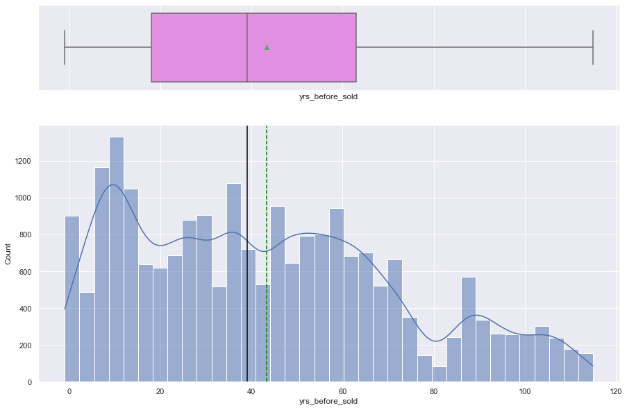

```python
histogram_boxplot(df, "yrs_before_sold")
```

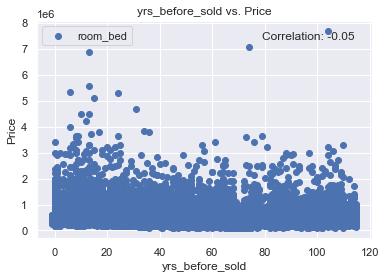

```python
# Function to calculate and display correlation
def calculate_and_display_correlation(x, y):
    correlation = df[x].corr(df[y])
    plt.text(0.95, 0.95, f'Correlation: {correlation:.2f}', transform=plt.gca().transAxes, ha='right', va='top')

# Plot yrs_before_sold vs. Price
plt.scatter(df['yrs_before_sold'], df['price'], label='room_bed', marker='o')
plt.title('yrs_before_sold vs. Price')
plt.xlabel('yrs_before_sold')
plt.ylabel('Price')
plt.legend()
calculate_and_display_correlation('yrs_before_sold', 'price')

# Show the plot
plt.show()
```

- No correlation